# milestone3_BERT_termX_replacement

## Load data

```python
from pathlib import Path
import pandas as pd


usecols = ['food_entity', 'disease_entity', 'sentence', 'is_cause', 'is_treat']
fd_df = pd.read_csv(
    Path('../data/food_disease.csv'),
    sep=',', quotechar='"',
    skipinitialspace=True,
    encoding='utf-8',
    on_bad_lines='skip',
    usecols=usecols).rename({'food_entity': 'term1', 'disease_entity': 'term2'}, axis=1)
fd_df['sentence'] = fd_df['sentence'].map(lambda x: x.lower())
fd_df = fd_df[fd_df.apply(lambda x: x['term1'] in x['sentence'] and x['term2'] in x['sentence'], axis=1)]
label_cols = ['is_cause', 'is_treat']
fd_df['is_cause'] = fd_df['is_cause'].astype(float).astype(int)
fd_df['is_treat'] = fd_df['is_treat'].astype(float).astype(int)

print(len(fd_df))
print(f"is_cause: {sum(fd_df['is_cause'])}")
print(f"is_treat: {sum(fd_df['is_treat'])}")
fd_df.head(3)
```

```
595
is_cause: 135
is_treat: 317
```

|  | term1 | term2 | sentence | is_cause | is_treat |
| --- | --- | --- | --- | --- | --- |
| 0 | bombax ceiba l. (bombacaceae) fruits | urinary stones | interestingly, many indian tribes use bombax c... | 0 | 1 |
| 1 | ultra-processed food | obesity | ultra-processed food consumption has been asso... | 1 | 0 |
| 2 | salt | osteoporosis | salt has notoriously been blamed for causing a... | 1 | 0 |

```python
df_cause = pd.read_csv(
    Path('../data/crowd_truth_cause.csv'),
    sep=',', quotechar='"',
    skipinitialspace=True,
    encoding='utf-8',
    on_bad_lines='skip',
    usecols=['sentence', 'term1', 'term2']
)
df_cause['is_cause'] = 1
df_cause['is_treat'] = 0
df_treat = pd.read_csv(
    Path('../data/crowd_truth_treat.csv'),
    sep=',', quotechar='"',
    skipinitialspace=True,
    encoding='utf-8',
    on_bad_lines='skip',
    usecols=['sentence', 'term1', 'term2']
)
df_treat['is_treat'] = 1
df_treat['is_cause'] = 0
ct_df = df_cause.append(df_treat, ignore_index=True)

print(len(ct_df))
print(len(ct_df))
print(f"is_cause: {sum(ct_df['is_cause'])}")
print(f"is_treat: {sum(ct_df['is_treat'])}")
ct_df.head(3)
```

```
7968
7968
is_cause: 3984
is_treat: 3984
```

|  | term1 | term2 | sentence | is_cause | is_treat |
| --- | --- | --- | --- | --- | --- |
| 0 | AUTISM | TANTRUM | The limited data suggest that, in children wit... | 1 | 0 |
| 1 | SLEEP PROBLEM | FAMILY STRESS | SLEEP PROBLEMs are associated with difficult b... | 1 | 0 |
| 2 | CEREBELLAR ATAXIA | DYSFUNCTION OF THE CEREBELLUM | The term CEREBELLAR ATAXIA is employed to indi... | 1 | 0 |

```python
fd_df['source'] = 'FoodDisease'
ct_df['source'] = 'CrowdTruth'
df = pd.concat([fd_df, ct_df])

term1 = 'term1'
term2 = 'term2'

df['prp_sent'] = df['sentence']
df['prp_sent'] = df.apply(lambda x: x['prp_sent'].replace(x['term1'], term1), axis=1)
df['prp_sent'] = df.apply(lambda x: x['prp_sent'].replace(x['term2'], term2), axis=1)
df = df[df['prp_sent'].apply(lambda x: term1 in x and term2 in x)]

print(len(df))
df.head(3)
```

```
8416
```

|  | term1 | term2 | sentence | is_cause | is_treat | source | prp_sent |
| --- | --- | --- | --- | --- | --- | --- | --- |
| 0 | bombax ceiba l. (bombacaceae) fruits | urinary stones | interestingly, many indian tribes use bombax c... | 0 | 1 | FoodDisease | interestingly, many indian tribes use term1 as... |
| 1 | ultra-processed food | obesity | ultra-processed food consumption has been asso... | 1 | 0 | FoodDisease | term1 consumption has been associated with sev... |
| 2 | salt | osteoporosis | salt has notoriously been blamed for causing a... | 1 | 0 | FoodDisease | term1 has notoriously been blamed for causing ... |

```python
# Edge case
df[(df['is_cause'] == 1) & (df['is_treat'] == 1)]
```

|  | term1 | term2 | sentence | is_cause | is_treat | source | prp_sent |
| --- | --- | --- | --- | --- | --- | --- | --- |
| 183 | dairy products | cardiometabolic diseases | dairy products contain both beneficial and har... | 1 | 1 | FoodDisease | term1 contain both beneficial and harmful nutr... |

```python
# Edge case
for i, row in df[(df['is_cause'] == 0) & (df['is_treat'] == 0)][['term1', 'term2', 'source', 'prp_sent']].iterrows():
    print(row.to_dict())
    if i > 50: break

df[(df['is_cause'] == 0) & (df['is_treat'] == 0)][['term1', 'term2', 'source', 'prp_sent']]
```

```
{'term1': 'broiler chicken', 'term2': 'footpad dermatitis', 'source': 'FoodDisease', 'prp_sent': 'in term1 flocks when animal-based measures related to term2, hock burns, body lesions and arthritis are identified under commercial conditions (high density).'}
{'term1': 'zinc', 'term2': 'mnds', 'source': 'FoodDisease', 'prp_sent': 'term2 remain a major public health concern particularly for women and children, with calcium, iodine, iron, selenium, term1, folate and vitamin a deficiencies being the most common.'}
{'term1': 'milk', 'term2': 'allergic', 'source': 'FoodDisease', 'prp_sent': 'while many egg and term1-term2 children tolerate baked egg (be) and term1 (bm), reactions elicited by these oral food challenges (ofcs) can be severe.'}
{'term1': 'tea infusion', 'term2': 'paraguariensis', 'source': 'FoodDisease', 'prp_sent': 'the results of the i. term2 infusions made at 65ã\x83â\x83ã\x82â\x82ã\x83â\x82ã\x82â°c and at 75ã\x83â\x83ã\x82â\x82ã\x83â\x82ã\x82â° c show that there was no significant difference between both temperatures w…
{'term1': 'significant alteration in food consumption', 'term2': 'subchronic oral toxicity', 'source': 'FoodDisease', 'prp_sent': 'in the term2, data revealed that several term1, water consumption, protein excretion, wbcs levels, tgs, bun levels, and the absolute and relative weights in the liver, s…
{'term1': 'breast milk', 'term2': 'transfusion-transmitted cmv (tt-cmv) infection', 'source': 'FoodDisease', 'prp_sent': 'although term1 is considered a major source of transmission, term2 is often suspected when cmv disease develops after transfusion.'}
{'term1': 'poultry', 'term2': 'bronchitis', 'source': 'FoodDisease', 'prp_sent': 'infectious term2 is one of the most common diseases in the term1 industry in many countries, especially in the regions with a dense term1 farming industry.'}
{'term1': 'fructose-rich food and beverages', 'term2': 'obesity', 'source': 'FoodDisease', 'prp_sent': 'risk factors include male sex; term2; hypertension; alcohol intake; diuretic use; a diet rich in meat and seafood; chronic kidney disease; a diet heavy in term1; being a member of certain ethnic g…
{'term1': 'eggs', 'term2': 'infectious bronchitis', 'source': 'FoodDisease', 'prp_sent': 'in 35 flocks comprising almost 100,000 white plymouth rock birds producing hatching term1, term2 (ib) caused a decline in production which appeared to be connected with the age of the birds, when the outbreak s…
{'term1': 'coffee', 'term2': 'kidney disease', 'source': 'FoodDisease', 'prp_sent': 'drinking term1 can raise public health problems, but the association between term1 and term2 is unknown.'}
```

|  | term1 | term2 | source | prp_sent |
| --- | --- | --- | --- | --- |
| 3 | broiler chicken | footpad dermatitis | FoodDisease | in term1 flocks when animal-based measures rel... |
| 11 | zinc | mnds | FoodDisease | term2 remain a major public health concern par... |
| 14 | milk | allergic | FoodDisease | while many egg and term1-term2 children tolera... |
| 27 | tea infusion | paraguariensis | FoodDisease | the results of the i. term2 infusions made at ... |
| 28 | significant alteration in food consumption | subchronic oral toxicity | FoodDisease | in the term2, data revealed that several term1... |
| ... | ... | ... | ... | ... |
| 583 | human milk | cow's milk protein allergy (cmpa) | FoodDisease | due to its similarity with term1 and its low a... |
| 585 | tea consumption | alzheimer disease | FoodDisease | for the recalculated meta-analyses, quality of... |
| 592 | ginkgo biloba | mci | FoodDisease | supplementation with vitamin e (one study, n 5... |
| 594 | limanda limanda | ulcerations | FoodDisease | aeromonas salmonicida was isolated from term2 ... |
| 604 | persea americana | wilting | FoodDisease | glasshouse pathogenicity tests with 'reed' avo... |

144 rows × 4 columns

```python
# !pip install spacy networkx
import spacy
import networkx as nx


nlp = spacy.load('en_core_web_sm')
doc = nlp(df['sentence'].iloc[0])

def shortest_dep_path(sentence):
    doc = nlp(sentence)
    edges = []
    for token in doc:
        for child in token.children:
            edges.append((
                '{0}'.format(token.lemma_),
                '{0}'.format(child.lemma_)))
    graph = nx.Graph(edges)
    entity1 = term1
    entity2 = term2
    try:
        return nx.shortest_path(graph, source=entity1, target=entity2)
    except Exception as e:
        return []

df['sdp'] = df['prp_sent'].apply(shortest_dep_path)
df = df[df['sdp'].apply(len) > 0]
df['sdp_joined'] = df['sdp'].apply(lambda x: ' '.join(x))
df.to_csv(Path('../data/milestone3/preprocessed.csv'), sep=';', index=False)

print(len(df))
df.head(3)
```

```
7978
```

|  | term1 | term2 | sentence | is_cause | is_treat | source | prp_sent | sdp | sdp_joined |
| --- | --- | --- | --- | --- | --- | --- | --- | --- | --- |
| 0 | bombax ceiba l. (bombacaceae) fruits | urinary stones | interestingly, many indian tribes use bombax c... | 0 | 1 | FoodDisease | interestingly, many indian tribes use term1 as... | [term1, use, as, medicine, for, treatment, of,... | term1 use as medicine for treatment of term2 |
| 1 | ultra-processed food | obesity | ultra-processed food consumption has been asso... | 1 | 0 | FoodDisease | term1 consumption has been associated with sev... | [term1, consumption, associate, with, outcome,... | term1 consumption associate with outcome as term2 |
| 2 | salt | osteoporosis | salt has notoriously been blamed for causing a... | 1 | 0 | FoodDisease | term1 has notoriously been blamed for causing ... | [term1, blame, for, term2] | term1 blame for term2 |

# Pretrained BERT features with SVM classifier

```python
from pathlib import Path
import pandas as pd


df = pd.read_csv(Path('../data/milestone3/preprocessed.csv'), sep=';')
df = df[df['source'] == 'FoodDisease']
# Try trick because model does not get to seem to get the directional order of 'term1'/'term2', use 'influence'/'condition' instead because influence causes/treats a condition
df['prp_sent'] = df['prp_sent'].apply(lambda x: x.replace('term1', 'influence'). replace('term2', 'condition'))
df['sdp_joined'] = df['sdp_joined'].apply(lambda x: x.replace('term1', 'influence'). replace('term2', 'condition'))
sent_features = df['prp_sent']
sdp_features = df['sdp_joined']
# Only food disease because CrowdTruth is too bad quality
labels = df[['is_cause', 'is_treat']]
df
```

|  | term1 | term2 | sentence | is_cause | is_treat | source | prp_sent | sdp | sdp_joined |
| --- | --- | --- | --- | --- | --- | --- | --- | --- | --- |
| 0 | bombax ceiba l. (bombacaceae) fruits | urinary stones | interestingly, many indian tribes use bombax c... | 0 | 1 | FoodDisease | interestingly, many indian tribes use influenc... | ['term1', 'use', 'as', 'medicine', 'for', 'tre... | influence use as medicine for treatment of con... |
| 1 | ultra-processed food | obesity | ultra-processed food consumption has been asso... | 1 | 0 | FoodDisease | influence consumption has been associated with... | ['term1', 'consumption', 'associate', 'with', ... | influence consumption associate with outcome a... |
| 2 | salt | osteoporosis | salt has notoriously been blamed for causing a... | 1 | 0 | FoodDisease | influence has notoriously been blamed for caus... | ['term1', 'blame', 'for', 'term2'] | influence blame for condition |
| 3 | broiler chicken | footpad dermatitis | in broiler chicken flocks when animal-based me... | 0 | 0 | FoodDisease | in influence flocks when animal-based measures... | ['term1', 'flock', 'in', 'identify', 'burn', '... | influence flock in identify burn , condition |
| 4 | sfp | diabetes | in short, this study demonstrated that sfp cou... | 0 | 1 | FoodDisease | in short, this study demonstrated that influen... | ['term1', 'develop', 'as', 'food', 'or', 'prev... | influence develop as food or prevention of con... |
| ... | ... | ... | ... | ... | ... | ... | ... | ... | ... |
| 583 | nuts | atherosclerosis | thus, the inclusion of food sources of dietary... | 0 | 1 | FoodDisease | thus, the inclusion of food sources of dietary... | ['term1', 'of', 'inclusion', 'improve', 'contr... | influence of inclusion improve contribute to r... |
| 584 | persea americana | wilting | glasshouse pathogenicity tests with 'reed' avo... | 0 | 0 | FoodDisease | glasshouse pathogenicity tests with 'reed' avo... | ['term1', 'seedling', 'confirm', 'be', 'cause'... | influence seedling confirm be cause stunt cond... |
| 585 | apple juice | asthma | intake of beverages with excess free fructose ... | 1 | 0 | FoodDisease | intake of beverages with excess free fructose ... | ['term1', 'include', 'fructose', 'with', 'term2'] | influence include fructose with condition |
| 586 | coffee | pd | however, some evidence exists regarding a pote... | 0 | 1 | FoodDisease | however, some evidence exists regarding a pote... | ['term1', 'acid', ',', 'exist', 'increase', 'r... | influence acid , exist increase risk condition |
| 587 | folic acid fortification | neural tube defects | there is no doubt that folic acid fortificatio... | 0 | 1 | FoodDisease | there is no doubt that influence can be effect... | ['term1', 'be', 'effective', 'for', 'reduce', ... | influence be effective for reduce incidence of... |

588 rows × 9 columns

```python
# !pip install transformers evaluate datasets
from transformers import AutoTokenizer, AutoModel, pipeline


# Use bert embeddings as features for SVC
# Here using shortest dep path makes sense because it gives context between the 2 entities in question

# https://github.com/EmilyAlsentzer/clinicalBERT
tokenizer = AutoTokenizer.from_pretrained('emilyalsentzer/Bio_ClinicalBERT')
model = AutoModel.from_pretrained('emilyalsentzer/Bio_ClinicalBERT')
pipe = pipeline('feature-extraction', model=model, tokenizer=tokenizer, binary_output=True)
```

[output not shown]

```python
from pathlib import Path
from tqdm.auto import tqdm
import pandas as pd
import numpy as np


# Calculate embeddings (takes long and files are GB size)
# Previous replacement of entities with 'term1' 'term2' probably has negative effect on result here
# BERT does not know how context of those terms from training

sent_embeddings = pipe(list(df['prp_sent']))
sent_embeddings = np.array([x[0][0] for x in sent_embeddings])
pd.DataFrame(sent_embeddings).to_csv(Path('../data/milestone3/sent_features.csv'))
```

```python
sdp_embeddings = pipe(list(df['sdp_joined']))
sdp_embeddings = np.array([x[0][0] for x in sdp_embeddings])
pd.DataFrame(sdp_embeddings).to_csv(Path('../data/milestone3/sdp_features.csv'))
```

```python
from pathlib import Path
import pandas as pd

df = pd.read_csv(Path('../data/milestone3/preprocessed.csv'), sep=';')
sdp_features = pd.read_csv(Path('../data/milestone3/sdp_features.csv')).drop('Unnamed: 0', axis=1)[df['source'] == 'FoodDisease']
sent_features = pd.read_csv(Path('../data/milestone3/sent_features.csv')).drop('Unnamed: 0', axis=1)[df['source'] == 'FoodDisease']

# Only food disease because CrowdTruth is too bad quality
labels = df[['is_cause', 'is_treat']][df['source'] == 'FoodDisease']
print(len(labels))
print(labels.sum(axis=0))
```

```
588
is_cause    132
is_treat    313
dtype: int64
```

## SDP

```python
import numpy as np
from sklearn.datasets import make_classification
from sklearn.preprocessing import StandardScaler
from sklearn.model_selection import GridSearchCV, KFold, train_test_split
from sklearn.pipeline import Pipeline
from sklearn.svm import LinearSVC
from sklearn.multioutput import MultiOutputClassifier


np.random.seed(1)

X_train, X_test, y_train, y_test = train_test_split(sdp_features, labels, test_size=0.1, shuffle=True, random_state=1)

param_grid = {
    'svc__estimator__C': [0.01, 0.1, 1]
}

pipe = Pipeline([
    ('scaler', StandardScaler()),
    ('svc', MultiOutputClassifier(LinearSVC(max_iter=1000)))
])

gscv = GridSearchCV(
    pipe, param_grid,
    cv=KFold(n_splits=10, shuffle=True, random_state=1), n_jobs=15, verbose=10
)

gscv.fit(X_train, y_train)
gscv.score(X_test, y_test)
```

```
Fitting 10 folds for each of 3 candidates, totalling 30 fits
```

```
0.6610169491525424
```

```python
import joblib


joblib.dump(gscv, Path('../data/milestone3/gscv_sdp.pkl'), compress=5)

print("Best parameters:", gscv.best_params_)
print("Best score:", gscv.best_score_)
```

```
Best parameters: {'svc__estimator__C': 0.01}
Best score: 0.5443033381712626
```

```python
#!pip install seaborn
from sklearn.metrics import accuracy_score, f1_score, precision_score, recall_score


pred_test = gscv.predict(X_test)

print(f"accuracy: {accuracy_score(y_test, pred_test)}")
```

```
accuracy: 0.6610169491525424
```

```python
from sklearn.metrics import classification_report
import warnings
warnings.filterwarnings('ignore')


print('Test set (SDP)')
print(classification_report(y_test, pred_test, target_names=['is_cause', 'is_treat']))
```

```
Test set (SDP)
              precision    recall  f1-score   support

    is_cause       0.78      0.50      0.61        14
    is_treat       0.74      0.79      0.76        33

   micro avg       0.75      0.70      0.73        47
   macro avg       0.76      0.64      0.69        47
weighted avg       0.75      0.70      0.72        47
 samples avg       0.55      0.56      0.55        47
```

```
accuracy: 0.847457627118644
```

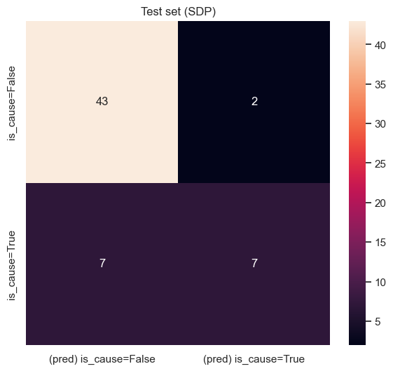

```python
import seaborn as sns
from sklearn.metrics import confusion_matrix


def evaluate_class(y, pred, class_name, title):
    print(f"accuracy: {accuracy_score(y, pred)}")

    conf_mat = confusion_matrix(y, pred)
    y_tick_labels = [f'{class_name}=False', f'{class_name}=True']
    x_tick_labels = ['(pred) ' + l for l in y_tick_labels]
    sns.set(rc={'figure.figsize':(7, 6)})
    sns.heatmap(conf_mat, xticklabels=x_tick_labels, yticklabels=y_tick_labels, annot=True, fmt='.3g'
        ).set(title=title)


evaluate_class(y_test.values[:, 0], pred_test[:, 0], 'is_cause', 'Test set (SDP)')
```

```
accuracy: 0.7288135593220338
```

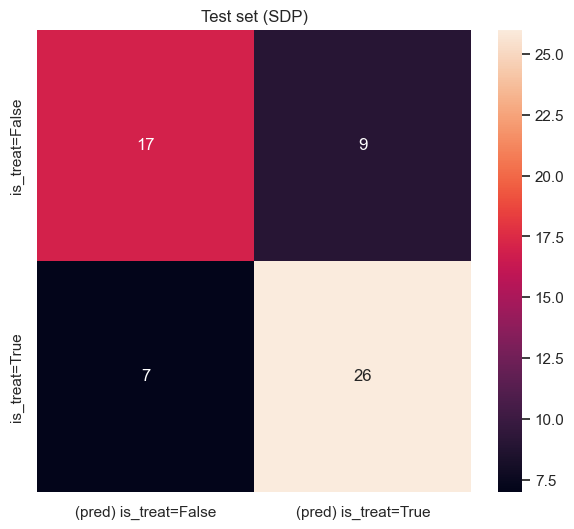

```python
evaluate_class(y_test.values[:, 1], pred_test[:, 1], 'is_treat', 'Test set (SDP)')
```

```python
# Where both are TRUE we could take the highest probability one, because we know that the double positive case is extremely unlikely
# It happens once though in the full dataset
```

```python
# Both predicted rightly
pd.set_option('display.max_colwidth', None)
print(f'len(y_test): {len(y_test)}')
cols = ['term1', 'term2', 'prp_sent', 'sdp_joined', 'is_cause', 'is_treat']
df[cols].iloc[y_test.index][(pred_test == y_test).all(axis=1)].sort_index()
```

```
len(y_test): 59
```

|  | term1 | term2 | prp_sent | sdp_joined | is_cause | is_treat |
| --- | --- | --- | --- | --- | --- | --- |
| 0 | bombax ceiba l. (bombacaceae) fruits | urinary stones | interestingly, many indian tribes use term1 as a traditional medicine for the treatment of term2. | term1 use as medicine for treatment of term2 | 0 | 1 |
| 17 | coffee | metabolic syndrome | further, waste products from tropical fruits including mangosteen rind, term1 pulp and spent term1 grounds provide further options to reduce term2. | term1 pulp rind , provide option reduce term2 | 0 | 1 |
| 47 | dairy products | bone diseases | however, milk is a food of high nutritional value, and complete exclusion of term1 may favor the development of term2 such as osteopenia and osteoporosis. | term1 of term2 | 0 | 1 |
| 49 | taraxacum officinale | inflammatory diseases | term1 (l.), commonly called dandelion has been used for centuries as a natural medicine to treat term2 including some metabolic alterations associated with obesity. | term1 use treat term2 | 0 | 1 |
| 59 | extra-virgin olive oil | malignancies | epidemiological studies have compellingly documented the ability of the mediterranean diet rich in term1 to reduce the incidence of certain term2, and cardiovascular diseases, and slow the alzheimer's… | term1 in rich diet of term2 | 0 | 1 |
| 65 | labiatae | cardiovascular diseases | use of term1 as food or food additives (such as spices) may prevent risk of term2, diabetes and cancer. | term1 of term2 | 0 | 1 |
| 90 | fermented foods | gut dysbiosis | regular consumption of term1 (e.g., kimchi, kefir, etc.) may represent a potential avenue to counter the proinflammatory effects of term2. | term1 of term2 | 0 | 1 |
| 92 | fruits | degenerative diseases | several studies have shown that a high consumption of vegetables and term1 is consistently associated with a low risk of oxidative stress-induced diseases, which includes some term2 such as amyotrophi… | term1 associate consumption of disease include term2 | 0 | 1 |
| 107 | tasmanian atlantic salmon (salmo salar) | viral diseases | the term1 aquaculture industry had remained relatively free of major term2 until the recent emergence of pilchard orthomyxovirus (pomv). | term1 industry the emergence of term2 | 0 | 0 |
| 111 | beef | bovine respiratory disease | term2 (brd) is a major cause of morbidity and mortality in term1 cattle. | term1 cattle in morbidity of cause be term2 | 0 | 0 |
| 120 | licorice | neurodegenerative diseases | extensive research over the last 10 years has indicated that nutraceuticals derived from such spices as turmeric, red pepper, black pepper, term1, clove, ginger, garlic, coriander, and cinnamon target… | term1 , prevent term2 | 0 | 1 |
| 124 | ginkgo biloba | cough | term1 has long been used in ancient china for the treatment of term2, asthma, and other lung diseases. | term1 use for treatment of term2 | 0 | 1 |
| 135 | whey protein | lipemia | recently, we demonstrated that term1 (wp) combined with low dietary fiber improved term2, a risk factor for cardiovascular disease in subjects with abdominal obesity. | term1 demonstrate , term2 | 0 | 1 |
| 165 | cigarette smoke | neurological diseases | exposure to term1 (cs) is associated with an increased risk of several term2 such as stroke, alzheimer's disease, and dementia. | term1 to exposure associate with risk of term2 | 1 | 0 |
| 172 | low diet quality | micronutrient malnutrition | term1 is a driver of general and term2 in urban and rural areas. | term1 be driver term2 | 1 | 0 |
| 195 | walnut | allergic reactions | jug r 1, the major allergen of term1, triggers severe term2 through epitopes. | term1 of allergen trigger term2 | 1 | 0 |
| 207 | chicken meat | osteoporosis | proteins and peptides in term1 and bones are known for being rich in functional and nutritional ingredients for the improvement of term2. | term1 in ingredient for improvement of term2 | 0 | 1 |
| 218 | malnutrition | cardiovascular disease | term1 is a condition most commonly arising from the inadequate consumption of nutrients necessary to maintain physiological health and is associated with the development of term2, osteoporosis, and sa… | term1 be and osteoporosis term2 | 1 | 0 |
| 236 | wheat | baker's rhinitis | term2 is a kind of occupational allergic rhinitis mainly caused by intranasal exposure to term1 and/or rye flour in bakery workers. | term1 to exposure by cause kind be term2 | 1 | 0 |
| 242 | diets rich in (poly)phenols | cardiovascular disorders | term1 are associated with a reduced reduction in the incidence of term2. | term1 associate with reduction in incidence of term2 | 0 | 1 |
| 257 | rice fortification | micronutrient deficiencies | term1 with vitamins and minerals has the potential to increase the nutrition in rice-consuming countries where term2 exist. | term1 have potential increase in country exist term2 | 0 | 1 |
| 283 | wheat | coeliac disease | term1 is one of the major crops grown, processed and consumed by humankind and is associated with both intolerances (notably term2) and allergies. | term1 be and intolerance term2 | 1 | 0 |
| 307 | extra virgin olive oil | myocardial infarction | in this context, term1 (evoo), the most representative component of this diet, seems to be relevant in lowering the incidence of cardiovascular events, including term2 and stroke. | term1 , event include term2 | 0 | 1 |
| 314 | alcohol | obesity | the association of term2, physical inactivity and term1 with elevated blood pressure (bp) is firmly established. | term1 inactivity association of term2 | 0 | 0 |
| 346 | olive oil | ckd | plant nutrients and plant-based diets could have beneficial effects in patients with term2: increased fibre intake shifts the gut microbiota towards reduced production of uraemic toxins; plant fats, p… | term1 fat have mitigate acidosis progression term2 | 0 | 1 |
| 382 | milk | mastitis | staphylococcus aureus is the leading cause of clinical term2 and is associated with persistent subclinical infections in ewes, significantly compromising the quality and quantity of term1 productions. | term1 production of term2 | 0 | 0 |
| 409 | unbalanced diet | neurodegenerative diseases | in the last decade, several theories investigating the causes of term2 have been formulated and a condition or risk factor that can contribute is described by the gut-brain axis hypothesis: stress, te… | term1 stress hypothesis the cause of term2 | 1 | 0 |
| 414 | farmed atlantic salmon | heart and skeletal muscle inflammation | piscine orthoreovirus (prv-1) can cause term2 (hsmi) in term1 ( | term1 in cause term2 | 0 | 0 |
| 424 | lemon seed | ige-mediated hypersensitivity | we report a case of term2 to term1. | term1 to report case of term2 | 0 | 0 |
| 438 | cheese | cvd | in subgroup analysis, term1 and yogurt consumptions were associated with decreased term2 risk (or = 0.87, 95% ci = 0.80-0.94 for term1 and or = 0. | term1 and ci risk term2 | 0 | 1 |
| 477 | fish | cognitive decline | epidemiological studies have presented inconsistent evidence of the correlation between a term1-oriented dietary intake (fdi) and the risk of term2. | term1 orient intake risk of term2 | 0 | 0 |
| 480 | garlic supplements | colorectal cancer | laboratory studies have provided evidence that allium vegetables and term1 might protect against term2 (crc), but epidemiologic studies have produced inconsistent findings. | term1 vegetable protect against term2 | 0 | 1 |
| 491 | garlic | colon, lung, and skin cancers | diallyl disulfide (dads), a component of term1 (allium sativum), has been known to exert potent chemopreventative activity against term2. | term1 of component disulfide know exert against term2 | 0 | 1 |
| 507 | green tea | infectious diseases | catechins, phytochemicals contained mainly in term1, exhibit antiviral activity against various acute term2 experimentally. | term1 in contain exhibit against term2 | 0 | 1 |
| 535 | nuts | chronic disease | although a high intake of plant foods such as fruits, vegetables, whole grains, term1, and legumes has been recommended for term2 prevention, it has been unclear what is the optimal amount of intake o… | term1 grain , intake recommend for prevention term2 | 0 | 1 |
| 538 | fruits | cvd | term2 can be prevented by some simple and cost-effective steps such as smoking cessation, normalizing body weight, regular physical activity, and dietary changes, including decreasing saturated fats, … | term1 vegetable and prevent term2 | 0 | 1 |
| 555 | milk | fracture | in adult caucasian women, daily intake of 200-250 ml of term1 is associated with a reduction in term2 risk of 5 % or higher. | term1 of risk term2 | 0 | 1 |
| 563 | oats | chronic diseases | term1 products are believed to contain many bioactives that possess potential beneficial properties against term2. | term1 product believe contain bioactive possess against term2 | 0 | 1 |
| 571 | milk | hip fracture | however, there is also evidence of a detrimental effect of term1 on the risk of term2. | term1 of term2 | 0 | 1 |

```python
df[cols].iloc[y_test.index][~(pred_test == y_test).all(axis=1)]# At least one predicted wrongly
df[cols].iloc[y_test.index][~(pred_test == y_test).all(axis=1)].assign(
    pred_is_cause=pred_test[~(pred_test == y_test).all(axis=1).values, 0],
    pred_is_treat=pred_test[~(pred_test == y_test).all(axis=1).values, 1]
).sort_index()
```

|  | term1 | term2 | prp_sent | sdp_joined | is_cause | is_treat | pred_is_cause | pred_is_treat |
| --- | --- | --- | --- | --- | --- | --- | --- | --- |
| 13 | excessive consumption of red meat | coronary heart diseases | term1 is associated with various diseases including term2 and cancer. | term1 associate with disease include term2 | 1 | 0 | 0 | 1 |
| 23 | excessive sugar consumption | metabolic diseases | since term1 has been related to the development of chronic term2 prevalent in the western world, the use of sweeteners has gradually increased worldwide over the last few years. | term1 relate to development of prevalent term2 | 0 | 1 | 1 | 0 |
| 41 | flour dust | respiratory diseases | for decades, occupational exposure to term1 has been linked to a range of term2, including occupational asthma, thought to result from exposure to fungi present in the flour. | term1 to range of term2 | 1 | 0 | 0 | 0 |
| 66 | meat | coronary heart disease | regular intake of foods rich in saturated fats, such as term1 and certain dairy products, raises the risk of term2, especially in smokers. | term1 as fat in risk of term2 | 1 | 0 | 0 | 1 |
| 88 | 3-hydroxyphenylpropionic acid | diabetes | epicatechin (ec) and main colonic phenolic acids derived from flavonoid intake, such as 2,3-dihydroxybenzoic acid (dhba), 3,4-dihydroxyphenylacetic acid (dhpaa) and term1 (hppa), have been suggested t… | term1 acid epicatechin suggest exert in term2 | 0 | 1 | 0 | 0 |
| 132 | hard water | atopic dermatitis | this review summarizes the mechanism and effects of dead sea salt, term1, commercial baby cleansers, oatmeal, rice, and natural oils as bathing additives for the treatment of term2. | term1 salt of term2 | 0 | 1 | 0 | 0 |
| 147 | fruit of lycium chinense (lc) | musculoskeletal diseases | the term1, one of the most popular natural materials, has been used to counter the effects of term2 in oriental medicine. | term1 one of term2 | 0 | 1 | 0 | 0 |
| 159 | olives | inflammation | consumption of term1 (olea europaea l.), including table term1 and oil, is associated with low incidence of term2-related diseases. | term1 of disease relate term2 | 0 | 1 | 0 | 0 |
| 173 | certain foods | obesity | portion sizes for term1 have been increasing dramatically in recent years alongside term2 rates, concurring with the phenomenon of the portion size effect (more is consumed when more is offered). | term1 for size increase in year alongside rate term2 | 1 | 0 | 0 | 1 |
| 179 | eicosapentaenoic acid | alzheimer's disease | abundant studies have highlighted the protective effects of docosahexaenoic acid (dha), in the form of glycerolipids (glycerophosphatides and triglycerides) and dha-ethyl esters (dha-ee) in term2 (ad)… | term1 epa ( term2 | 0 | 0 | 0 | 1 |
| 187 | noni fruit juice | rheumatoid arthritis | however, the validity of term1 as a treatment for term2 (ra), an autoimmune disorder, has not been confirmed yet. | term1 of validity as treatment for term2 | 0 | 0 | 0 | 1 |
| 189 | dark chocolate | t2d | while it could be suggested that daily consumption of flavanols from cocoa or term1 would constitute a potential preventive tool useful for the nutritional management of term2, this recommendation sho… | term1 cocoa product of term2 | 0 | 1 | 0 | 0 |
| 247 | dietary sugar | dental caries | term1, especially in liquid form, increases risk of term2, adiposity, and type 2 diabetes. | term1 , term2 | 1 | 0 | 0 | 1 |
| 262 | alcohol | carcinogenic | high consumption of red meat, which is term2 to humans, and misuse or abuse of term1 drinking increase premature death and shortened life expectancy. | term1 of consumption be term2 | 0 | 0 | 0 | 1 |
| 277 | alcohol | osteoporosis | the results reported in this study show the influence of gender, place of residence, smoking, consumption of term1, arthroscopy surgery, term2, and rheumatoid arthritis on the fe, ni, mo, and v concen… | term1 of place smoking surgery term2 | 0 | 0 | 0 | 1 |
| 305 | mustard | allergies | peanuts and nuts cause a great part of term2 in the united states; in spain and portugal are commonly due to fish, milk; in italy seafood and term1 in france. | term1 seafood in cause part of term2 | 1 | 0 | 0 | 0 |
| 434 | nobiletin from citrus peels | dementia | previously, we identified term1 as a natural compound possessing anti-term2 activity. | term1 identify as compound possess activity term2 | 0 | 1 | 1 | 1 |
| 460 | wheat flour | allergy | occupational term2 to components of term1 is the main cause of rhinitis and asthma of workers in bakeries and similar activities. | term1 of component to term2 | 1 | 0 | 0 | 0 |
| 530 | coffee | neurodegenerative diseases | our findings strongly suggest that some foods, especially term1, can act as a rich source of ãâãâãâãâ²-carbolines, which may possibly be associated with a reduced risk for serious term2, such a… | term1 food , term2 | 0 | 1 | 0 | 0 |
| 543 | pharmaceutical drugs | hyperuricemia | while term1 have been shown to exhibit serious side effects, and bioactive compounds from plant-based functional foods have been demonstrated to be active in the treatment of term2 with only minimal s… | term1 show be in treatment of term2 | 0 | 0 | 0 | 1 |

## Full sentence

```python
import numpy as np
from sklearn.datasets import make_classification
from sklearn.preprocessing import StandardScaler
from sklearn.model_selection import GridSearchCV, KFold, train_test_split
from sklearn.pipeline import Pipeline
from sklearn.svm import LinearSVC
from sklearn.multioutput import MultiOutputClassifier
from sklearn.metrics import confusion_matrix, make_scorer


np.random.seed(1)

X_train, X_test, y_train, y_test = train_test_split(sent_features, labels, test_size=0.1, shuffle=True, random_state=1)

param_grid = {
    'svc__estimator__C': [0.01, 0.1, 1]
}

pipe = Pipeline([
    ('scaler', StandardScaler()),
    ('svc', MultiOutputClassifier(LinearSVC()))
])

gscv = GridSearchCV(
    pipe, param_grid,
    cv=KFold(n_splits=10, shuffle=True, random_state=1), n_jobs=15, verbose=3
)

gscv.fit(X_train, y_train)
gscv.score(X_test, y_test)
```

```
Fitting 10 folds for each of 3 candidates, totalling 30 fits
```

```
0.6610169491525424
```

```python
joblib.dump(gscv, Path('../data/milestone3/gscv_sent.pkl'), compress=5)

print("Best parameters:", gscv.best_params_)
print("Best score:", gscv.best_score_)
```

```
Best parameters: {'svc__estimator__C': 0.01}
Best score: 0.7125907111756168
```

```python
#!pip install seaborn
import seaborn as sns
from sklearn.metrics import accuracy_score, f1_score, precision_score, recall_score


pred_test = gscv.predict(X_test)

print(f"accuracy: {accuracy_score(y_test, pred_test)}")
```

```
accuracy: 0.6610169491525424
```

```python
from sklearn.metrics import classification_report
import warnings
warnings.filterwarnings('ignore')


print('Test set (full sentence)')
print(classification_report(y_test, pred_test, target_names=['is_cause', 'is_treat']))
```

```
Test set (full sentence)
              precision    recall  f1-score   support

    is_cause       0.54      0.93      0.68        14
    is_treat       0.89      0.76      0.82        33

   micro avg       0.73      0.81      0.77        47
   macro avg       0.72      0.84      0.75        47
weighted avg       0.79      0.81      0.78        47
 samples avg       0.60      0.64      0.62        47
```

```
accuracy: 0.7966101694915254
```

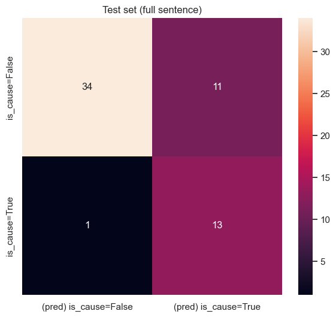

```python
evaluate_class(y_test.values[:, 0], pred_test[:, 0], 'is_cause', 'Test set (full sentence)')
```

```
accuracy: 0.8135593220338984
```

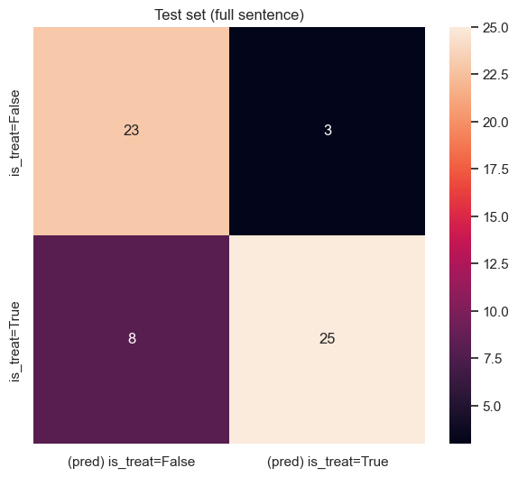

```python
evaluate_class(y_test.values[:, 1], pred_test[:, 1], 'is_treat', 'Test set (full sentence)')
```

```python
# Both predicted rightly
pd.set_option('display.max_colwidth', None)
print(f'len(y_test): {len(y_test)}')
cols = ['term1', 'term2', 'prp_sent', 'sdp_joined', 'is_cause', 'is_treat']
df[cols].iloc[y_test.index][(pred_test == y_test).all(axis=1)].sort_index()
```

```
len(y_test): 59
```

|  | term1 | term2 | prp_sent | sdp_joined | is_cause | is_treat |
| --- | --- | --- | --- | --- | --- | --- |
| 0 | bombax ceiba l. (bombacaceae) fruits | urinary stones | interestingly, many indian tribes use term1 as a traditional medicine for the treatment of term2. | term1 use as medicine for treatment of term2 | 0 | 1 |
| 13 | excessive consumption of red meat | coronary heart diseases | term1 is associated with various diseases including term2 and cancer. | term1 associate with disease include term2 | 1 | 0 |
| 17 | coffee | metabolic syndrome | further, waste products from tropical fruits including mangosteen rind, term1 pulp and spent term1 grounds provide further options to reduce term2. | term1 pulp rind , provide option reduce term2 | 0 | 1 |
| 41 | flour dust | respiratory diseases | for decades, occupational exposure to term1 has been linked to a range of term2, including occupational asthma, thought to result from exposure to fungi present in the flour. | term1 to range of term2 | 1 | 0 |
| 49 | taraxacum officinale | inflammatory diseases | term1 (l.), commonly called dandelion has been used for centuries as a natural medicine to treat term2 including some metabolic alterations associated with obesity. | term1 use treat term2 | 0 | 1 |
| 59 | extra-virgin olive oil | malignancies | epidemiological studies have compellingly documented the ability of the mediterranean diet rich in term1 to reduce the incidence of certain term2, and cardiovascular diseases, and slow the alzheimer's… | term1 in rich diet of term2 | 0 | 1 |
| 66 | meat | coronary heart disease | regular intake of foods rich in saturated fats, such as term1 and certain dairy products, raises the risk of term2, especially in smokers. | term1 as fat in risk of term2 | 1 | 0 |
| 88 | 3-hydroxyphenylpropionic acid | diabetes | epicatechin (ec) and main colonic phenolic acids derived from flavonoid intake, such as 2,3-dihydroxybenzoic acid (dhba), 3,4-dihydroxyphenylacetic acid (dhpaa) and term1 (hppa), have been suggested t… | term1 acid epicatechin suggest exert in term2 | 0 | 1 |
| 90 | fermented foods | gut dysbiosis | regular consumption of term1 (e.g., kimchi, kefir, etc.) may represent a potential avenue to counter the proinflammatory effects of term2. | term1 of term2 | 0 | 1 |
| 111 | beef | bovine respiratory disease | term2 (brd) is a major cause of morbidity and mortality in term1 cattle. | term1 cattle in morbidity of cause be term2 | 0 | 0 |
| 120 | licorice | neurodegenerative diseases | extensive research over the last 10 years has indicated that nutraceuticals derived from such spices as turmeric, red pepper, black pepper, term1, clove, ginger, garlic, coriander, and cinnamon target… | term1 , prevent term2 | 0 | 1 |
| 147 | fruit of lycium chinense (lc) | musculoskeletal diseases | the term1, one of the most popular natural materials, has been used to counter the effects of term2 in oriental medicine. | term1 one of term2 | 0 | 1 |
| 159 | olives | inflammation | consumption of term1 (olea europaea l.), including table term1 and oil, is associated with low incidence of term2-related diseases. | term1 of disease relate term2 | 0 | 1 |
| 165 | cigarette smoke | neurological diseases | exposure to term1 (cs) is associated with an increased risk of several term2 such as stroke, alzheimer's disease, and dementia. | term1 to exposure associate with risk of term2 | 1 | 0 |
| 172 | low diet quality | micronutrient malnutrition | term1 is a driver of general and term2 in urban and rural areas. | term1 be driver term2 | 1 | 0 |
| 173 | certain foods | obesity | portion sizes for term1 have been increasing dramatically in recent years alongside term2 rates, concurring with the phenomenon of the portion size effect (more is consumed when more is offered). | term1 for size increase in year alongside rate term2 | 1 | 0 |
| 187 | noni fruit juice | rheumatoid arthritis | however, the validity of term1 as a treatment for term2 (ra), an autoimmune disorder, has not been confirmed yet. | term1 of validity as treatment for term2 | 0 | 0 |
| 189 | dark chocolate | t2d | while it could be suggested that daily consumption of flavanols from cocoa or term1 would constitute a potential preventive tool useful for the nutritional management of term2, this recommendation sho… | term1 cocoa product of term2 | 0 | 1 |
| 195 | walnut | allergic reactions | jug r 1, the major allergen of term1, triggers severe term2 through epitopes. | term1 of allergen trigger term2 | 1 | 0 |
| 207 | chicken meat | osteoporosis | proteins and peptides in term1 and bones are known for being rich in functional and nutritional ingredients for the improvement of term2. | term1 in ingredient for improvement of term2 | 0 | 1 |
| 218 | malnutrition | cardiovascular disease | term1 is a condition most commonly arising from the inadequate consumption of nutrients necessary to maintain physiological health and is associated with the development of term2, osteoporosis, and sa… | term1 be and osteoporosis term2 | 1 | 0 |
| 236 | wheat | baker's rhinitis | term2 is a kind of occupational allergic rhinitis mainly caused by intranasal exposure to term1 and/or rye flour in bakery workers. | term1 to exposure by cause kind be term2 | 1 | 0 |
| 242 | diets rich in (poly)phenols | cardiovascular disorders | term1 are associated with a reduced reduction in the incidence of term2. | term1 associate with reduction in incidence of term2 | 0 | 1 |
| 247 | dietary sugar | dental caries | term1, especially in liquid form, increases risk of term2, adiposity, and type 2 diabetes. | term1 , term2 | 1 | 0 |
| 257 | rice fortification | micronutrient deficiencies | term1 with vitamins and minerals has the potential to increase the nutrition in rice-consuming countries where term2 exist. | term1 have potential increase in country exist term2 | 0 | 1 |
| 277 | alcohol | osteoporosis | the results reported in this study show the influence of gender, place of residence, smoking, consumption of term1, arthroscopy surgery, term2, and rheumatoid arthritis on the fe, ni, mo, and v concen… | term1 of place smoking surgery term2 | 0 | 0 |
| 283 | wheat | coeliac disease | term1 is one of the major crops grown, processed and consumed by humankind and is associated with both intolerances (notably term2) and allergies. | term1 be and intolerance term2 | 1 | 0 |
| 305 | mustard | allergies | peanuts and nuts cause a great part of term2 in the united states; in spain and portugal are commonly due to fish, milk; in italy seafood and term1 in france. | term1 seafood in cause part of term2 | 1 | 0 |
| 314 | alcohol | obesity | the association of term2, physical inactivity and term1 with elevated blood pressure (bp) is firmly established. | term1 inactivity association of term2 | 0 | 0 |
| 346 | olive oil | ckd | plant nutrients and plant-based diets could have beneficial effects in patients with term2: increased fibre intake shifts the gut microbiota towards reduced production of uraemic toxins; plant fats, p… | term1 fat have mitigate acidosis progression term2 | 0 | 1 |
| 382 | milk | mastitis | staphylococcus aureus is the leading cause of clinical term2 and is associated with persistent subclinical infections in ewes, significantly compromising the quality and quantity of term1 productions. | term1 production of term2 | 0 | 0 |
| 434 | nobiletin from citrus peels | dementia | previously, we identified term1 as a natural compound possessing anti-term2 activity. | term1 identify as compound possess activity term2 | 0 | 1 |
| 460 | wheat flour | allergy | occupational term2 to components of term1 is the main cause of rhinitis and asthma of workers in bakeries and similar activities. | term1 of component to term2 | 1 | 0 |
| 477 | fish | cognitive decline | epidemiological studies have presented inconsistent evidence of the correlation between a term1-oriented dietary intake (fdi) and the risk of term2. | term1 orient intake risk of term2 | 0 | 0 |
| 480 | garlic supplements | colorectal cancer | laboratory studies have provided evidence that allium vegetables and term1 might protect against term2 (crc), but epidemiologic studies have produced inconsistent findings. | term1 vegetable protect against term2 | 0 | 1 |
| 507 | green tea | infectious diseases | catechins, phytochemicals contained mainly in term1, exhibit antiviral activity against various acute term2 experimentally. | term1 in contain exhibit against term2 | 0 | 1 |
| 530 | coffee | neurodegenerative diseases | our findings strongly suggest that some foods, especially term1, can act as a rich source of ãâãâãâãâ²-carbolines, which may possibly be associated with a reduced risk for serious term2, such a… | term1 food , term2 | 0 | 1 |
| 538 | fruits | cvd | term2 can be prevented by some simple and cost-effective steps such as smoking cessation, normalizing body weight, regular physical activity, and dietary changes, including decreasing saturated fats, … | term1 vegetable and prevent term2 | 0 | 1 |
| 563 | oats | chronic diseases | term1 products are believed to contain many bioactives that possess potential beneficial properties against term2. | term1 product believe contain bioactive possess against term2 | 0 | 1 |

```python
# At least one predicted wrongly
df[cols].iloc[y_test.index][~(pred_test == y_test).all(axis=1)].assign(
    pred_is_cause=pred_test[~(pred_test == y_test).all(axis=1).values, 0],
    pred_is_treat=pred_test[~(pred_test == y_test).all(axis=1).values, 1]
).sort_index()
```

|  | term1 | term2 | prp_sent | sdp_joined | is_cause | is_treat | pred_is_cause | pred_is_treat |
| --- | --- | --- | --- | --- | --- | --- | --- | --- |
| 23 | excessive sugar consumption | metabolic diseases | since term1 has been related to the development of chronic term2 prevalent in the western world, the use of sweeteners has gradually increased worldwide over the last few years. | term1 relate to development of prevalent term2 | 0 | 1 | 1 | 0 |
| 47 | dairy products | bone diseases | however, milk is a food of high nutritional value, and complete exclusion of term1 may favor the development of term2 such as osteopenia and osteoporosis. | term1 of term2 | 0 | 1 | 0 | 0 |
| 65 | labiatae | cardiovascular diseases | use of term1 as food or food additives (such as spices) may prevent risk of term2, diabetes and cancer. | term1 of term2 | 0 | 1 | 1 | 1 |
| 92 | fruits | degenerative diseases | several studies have shown that a high consumption of vegetables and term1 is consistently associated with a low risk of oxidative stress-induced diseases, which includes some term2 such as amyotrophi… | term1 associate consumption of disease include term2 | 0 | 1 | 0 | 0 |
| 107 | tasmanian atlantic salmon (salmo salar) | viral diseases | the term1 aquaculture industry had remained relatively free of major term2 until the recent emergence of pilchard orthomyxovirus (pomv). | term1 industry the emergence of term2 | 0 | 0 | 0 | 1 |
| 124 | ginkgo biloba | cough | term1 has long been used in ancient china for the treatment of term2, asthma, and other lung diseases. | term1 use for treatment of term2 | 0 | 1 | 1 | 1 |
| 132 | hard water | atopic dermatitis | this review summarizes the mechanism and effects of dead sea salt, term1, commercial baby cleansers, oatmeal, rice, and natural oils as bathing additives for the treatment of term2. | term1 salt of term2 | 0 | 1 | 0 | 0 |
| 135 | whey protein | lipemia | recently, we demonstrated that term1 (wp) combined with low dietary fiber improved term2, a risk factor for cardiovascular disease in subjects with abdominal obesity. | term1 demonstrate , term2 | 0 | 1 | 1 | 0 |
| 179 | eicosapentaenoic acid | alzheimer's disease | abundant studies have highlighted the protective effects of docosahexaenoic acid (dha), in the form of glycerolipids (glycerophosphatides and triglycerides) and dha-ethyl esters (dha-ee) in term2 (ad)… | term1 epa ( term2 | 0 | 0 | 0 | 1 |
| 262 | alcohol | carcinogenic | high consumption of red meat, which is term2 to humans, and misuse or abuse of term1 drinking increase premature death and shortened life expectancy. | term1 of consumption be term2 | 0 | 0 | 1 | 0 |
| 307 | extra virgin olive oil | myocardial infarction | in this context, term1 (evoo), the most representative component of this diet, seems to be relevant in lowering the incidence of cardiovascular events, including term2 and stroke. | term1 , event include term2 | 0 | 1 | 0 | 0 |
| 409 | unbalanced diet | neurodegenerative diseases | in the last decade, several theories investigating the causes of term2 have been formulated and a condition or risk factor that can contribute is described by the gut-brain axis hypothesis: stress, te… | term1 stress hypothesis the cause of term2 | 1 | 0 | 0 | 0 |
| 414 | farmed atlantic salmon | heart and skeletal muscle inflammation | piscine orthoreovirus (prv-1) can cause term2 (hsmi) in term1 ( | term1 in cause term2 | 0 | 0 | 1 | 0 |
| 424 | lemon seed | ige-mediated hypersensitivity | we report a case of term2 to term1. | term1 to report case of term2 | 0 | 0 | 1 | 0 |
| 438 | cheese | cvd | in subgroup analysis, term1 and yogurt consumptions were associated with decreased term2 risk (or = 0.87, 95% ci = 0.80-0.94 for term1 and or = 0. | term1 and ci risk term2 | 0 | 1 | 1 | 1 |
| 491 | garlic | colon, lung, and skin cancers | diallyl disulfide (dads), a component of term1 (allium sativum), has been known to exert potent chemopreventative activity against term2. | term1 of component disulfide know exert against term2 | 0 | 1 | 1 | 1 |
| 535 | nuts | chronic disease | although a high intake of plant foods such as fruits, vegetables, whole grains, term1, and legumes has been recommended for term2 prevention, it has been unclear what is the optimal amount of intake o… | term1 grain , intake recommend for prevention term2 | 0 | 1 | 0 | 0 |
| 543 | pharmaceutical drugs | hyperuricemia | while term1 have been shown to exhibit serious side effects, and bioactive compounds from plant-based functional foods have been demonstrated to be active in the treatment of term2 with only minimal s… | term1 show be in treatment of term2 | 0 | 0 | 0 | 1 |
| 555 | milk | fracture | in adult caucasian women, daily intake of 200-250 ml of term1 is associated with a reduction in term2 risk of 5 % or higher. | term1 of risk term2 | 0 | 1 | 1 | 1 |
| 571 | milk | hip fracture | however, there is also evidence of a detrimental effect of term1 on the risk of term2. | term1 of term2 | 0 | 1 | 1 | 0 |

```python
df[cols].iloc[y_test.index][~(pred_test == y_test).all(axis=1)].assign(
    pred_is_cause=pred_test[~(pred_test == y_test).all(axis=1).values, 0],
    pred_is_treat=pred_test[~(pred_test == y_test).all(axis=1).values, 1]
).iloc[1].to_dict()
```

```
{'term1': 'milk',
 'term2': 'fracture',
 'prp_sent': 'in adult caucasian women, daily intake of 200-250 ml of term1 is associated with a reduction in term2 risk of 5 % or higher.',
 'sdp_joined': 'term1 of risk term2',
 'is_cause': 0,
 'is_treat': 1,
 'pred_is_cause': 1,
 'pred_is_treat': 1}
```

## Interpretation of results

SDP should more robust, because it seems the CLS embedding contains an excellent understanding of which words are in the input and SDP has lesser occurrence of other potentially distracting words. The CLS embedding at least is like a better BOW, maybe because it understands individual words and their function in the sentence better. Judging by the good performance compared to our NaiveBayes BoW baseline, it seems to even understand the order and context of words, but at least not in the context of our replacement terms, which BERT was not trained with. It probably would not do better without the replacement either, because confusion arises from the predicted relation being true for some entities in the sentence, just not for our candidates.

For example in:

```
'term1': 'chicken',
 'term2': 'infectious bronchitis virus',
 'prp_sent': 'term2 (ibv), a gamma-coronavirus, causes infectious bronchitis (ib), a major respiratory disease of term1.',
 'sdp_joined': 'term1 of disease bronchitis cause term2',
 'is_cause': 0,
 'is_treat': 0,
 'pred_is_cause': 1,
 'pred_is_treat': 0
```

```
'term1': 'milk',
 'term2': 'fracture',
 'prp_sent': 'in adult caucasian women, daily intake of 200-250 ml of term1 is associated with a reduction in term2 risk of 5 % or higher.',
 'sdp_joined': 'term1 of risk term2',
 'is_cause': 0,
 'is_treat': 1,
 'pred_is_cause': 1,
 'pred_is_treat': 1
```

It understands that something is causing something bad, but does not understand that there still is no direct relation between the terms. But for 2 other candidates like 'gamma-coronavirus' and 'infectious bronchitis (ib)' the prediction would be correct. In this case it actually concerns both the full sentences and the SDP, but in general it should mostly concern the full sentences.

# Finetuned BERT with classification head

```python
from pathlib import Path
import pandas as pd


df = pd.read_csv(Path('../data/milestone3/preprocessed.csv'), sep=';')
df = df[df['source'] == 'FoodDisease']
# Try trick because model does not get to seem to get the directional order of 'term1'/'term2', use 'influence'/'condition' instead because influence causes/treats a condition
# df['prp_sent'] = df['prp_sent'].apply(lambda x: x.replace('term1', 'influence'). replace('term2', 'condition'))
sent_features = df['prp_sent']
sdp_features = df['sdp_joined']
# Only food disease because CrowdTruth is too bad quality
labels = df[['is_cause', 'is_treat']]
df
```

|  | term1 | term2 | sentence | is_cause | is_treat | source | prp_sent | sdp | sdp_joined |
| --- | --- | --- | --- | --- | --- | --- | --- | --- | --- |
| 0 | bombax ceiba l. (bombacaceae) fruits | urinary stones | interestingly, many indian tribes use bombax c... | 0 | 1 | FoodDisease | interestingly, many indian tribes use term1 as... | ['term1', 'use', 'as', 'medicine', 'for', 'tre... | term1 use as medicine for treatment of term2 |
| 1 | ultra-processed food | obesity | ultra-processed food consumption has been asso... | 1 | 0 | FoodDisease | term1 consumption has been associated with sev... | ['term1', 'consumption', 'associate', 'with', ... | term1 consumption associate with outcome as term2 |
| 2 | salt | osteoporosis | salt has notoriously been blamed for causing a... | 1 | 0 | FoodDisease | term1 has notoriously been blamed for causing ... | ['term1', 'blame', 'for', 'term2'] | term1 blame for term2 |
| 3 | broiler chicken | footpad dermatitis | in broiler chicken flocks when animal-based me... | 0 | 0 | FoodDisease | in term1 flocks when animal-based measures rel... | ['term1', 'flock', 'in', 'identify', 'burn', '... | term1 flock in identify burn , term2 |
| 4 | sfp | diabetes | in short, this study demonstrated that sfp cou... | 0 | 1 | FoodDisease | in short, this study demonstrated that term1 c... | ['term1', 'develop', 'as', 'food', 'or', 'prev... | term1 develop as food or prevention of term2 |
| ... | ... | ... | ... | ... | ... | ... | ... | ... | ... |
| 583 | nuts | atherosclerosis | thus, the inclusion of food sources of dietary... | 0 | 1 | FoodDisease | thus, the inclusion of food sources of dietary... | ['term1', 'of', 'inclusion', 'improve', 'contr... | term1 of inclusion improve contribute to reduc... |
| 584 | persea americana | wilting | glasshouse pathogenicity tests with 'reed' avo... | 0 | 0 | FoodDisease | glasshouse pathogenicity tests with 'reed' avo... | ['term1', 'seedling', 'confirm', 'be', 'cause'... | term1 seedling confirm be cause stunt term2 |
| 585 | apple juice | asthma | intake of beverages with excess free fructose ... | 1 | 0 | FoodDisease | intake of beverages with excess free fructose ... | ['term1', 'include', 'fructose', 'with', 'term2'] | term1 include fructose with term2 |
| 586 | coffee | pd | however, some evidence exists regarding a pote... | 0 | 1 | FoodDisease | however, some evidence exists regarding a pote... | ['term1', 'acid', ',', 'exist', 'increase', 'r... | term1 acid , exist increase risk term2 |
| 587 | folic acid fortification | neural tube defects | there is no doubt that folic acid fortificatio... | 0 | 1 | FoodDisease | there is no doubt that term1 can be effective ... | ['term1', 'be', 'effective', 'for', 'reduce', ... | term1 be effective for reduce incidence of term2 |

588 rows × 9 columns

## Huggingface BertForSequenceClassification

```python
# https://huggingface.co/docs/transformers/training

from pathlib import Path
import pandas as pd
import numpy as np
from transformers import AutoModelForSequenceClassification, AutoTokenizer, BertForSequenceClassification, BertTokenizer
import evaluate
from datasets import Dataset
import torch
from sklearn.model_selection import train_test_split

torch.manual_seed(1)
np.random.seed(1)

model = BertForSequenceClassification.from_pretrained(
    'emilyalsentzer/Bio_ClinicalBERT', num_labels=2, problem_type='multi_label_classification'
)
# for param in model.bert.parameters():
#     param.requires_grad = True
tokenizer = BertTokenizer.from_pretrained('emilyalsentzer/Bio_ClinicalBERT')
# bert = AutoModel.from_pretrained('emilyalsentzer/Bio_ClinicalBERT')

X_train, X_test, y_train, y_test = train_test_split(sent_features, labels.values, test_size=0.1, shuffle=True, random_state=1)
X_train, X_val, y_train, y_val = train_test_split(X_train, y_train, test_size=0.1, shuffle=True, random_state=1)

X_train_tokens = tokenizer(list(X_train), truncation=True, padding=True)
X_val_tokens = tokenizer(list(X_val), truncation=True, padding=True)
X_test_tokens = tokenizer(list(X_test), truncation=True, padding=True)


class MedDataset(torch.utils.data.Dataset):
    def __init__(self, encodings, labels):
        self.encodings = encodings
        self.labels = labels.astype('float')

    def __getitem__(self, idx):
        item = {key: torch.tensor(val[idx]) for key, val in self.encodings.items()}
        item['labels'] = torch.tensor(self.labels[idx])
        return item

    def __len__(self):
        return len(self.labels)


train_dataset = MedDataset(X_train_tokens, y_train)
val_dataset = MedDataset(X_val_tokens, y_val)
test_dataset = MedDataset(X_test_tokens, y_test)
```

[output not shown]

```python
from transformers import Trainer, TrainingArguments, EarlyStoppingCallback
from sklearn.metrics import f1_score, accuracy_score


training_args = TrainingArguments(
    output_dir='../data/milestone3/model/',
    num_train_epochs=50,
    per_device_train_batch_size=32,
    per_device_eval_batch_size=64,
    learning_rate=1e-4,
    weight_decay=1e-2,
    lr_scheduler_type='linear',
    warmup_steps=500,
    logging_dir='../data/milestone3/model/logs/',
    logging_steps=10,
    load_best_model_at_end=True,
    evaluation_strategy='epoch',
    save_strategy='epoch'
)

accuracy_metric = evaluate.load('accuracy')
f1_metric = evaluate.load('f1')
def compute_metrics(eval_pred):
    logits, labels = eval_pred
    probs = torch.sigmoid(torch.Tensor(logits))
    predictions = np.zeros(probs.shape)
    positive_mask = probs >= 0.5
    predictions[positive_mask] = 1
    predictions[~positive_mask] = 0
    result = {}
    label_cols = ['is_cause', 'is_treat']
    for i, l in enumerate(label_cols):
        result[f'accuracy {l}'] = accuracy_metric.compute(predictions=predictions[:, i], references=labels[:, i])['accuracy']
        result[f'f1 {l}'] = f1_metric.compute(predictions=predictions[:, i], references=labels[:, i])['f1']
    result[f'accuracy macro'] = sum([result[f'accuracy {l}'] for l in label_cols]) / len(label_cols)
    result['accuracy'] = accuracy_score(labels, predictions)
    result['f1_micro'] = f1_score(y_true=labels, y_pred=predictions, average='micro')
    return result


trainer = Trainer(
    model=model,
    args=training_args,
    train_dataset=train_dataset,
    eval_dataset=val_dataset,
    compute_metrics=compute_metrics,
    callbacks = [EarlyStoppingCallback(early_stopping_patience=5)]
)

trainer.train()
```

```
{'loss': 0.8096, 'learning_rate': 2.0000000000000003e-06, 'epoch': 0.67}
```

```
***** Running Evaluation *****
  Num examples = 53
  Batch size = 64
```

```
Saving model checkpoint to ../data/milestone3/model/checkpoint-15
Configuration saved in ../data/milestone3/model/checkpoint-15\config.json
```

```
{'eval_loss': 0.7729476101274759, 'eval_accuracy is_cause': 0.16981132075471697, 'eval_f1 is_cause': 0.2903225806451613, 'eval_accuracy is_treat': 0.5471698113207547, 'eval_f1 is_treat': 0.7000000000000002, 'eval_accuracy macro': 0.3584905660377358, 'eval_accuracy': 0.0, 'eval_f1_micro': 0.521126760…
```

```
Model weights saved in ../data/milestone3/model/checkpoint-15\pytorch_model.bin
```

```
{'loss': 0.7747, 'learning_rate': 4.000000000000001e-06, 'epoch': 1.33}
```

```
***** Running Evaluation *****
  Num examples = 53
  Batch size = 64
```

```
{'loss': 0.7043, 'learning_rate': 6e-06, 'epoch': 2.0}
```

```
Saving model checkpoint to ../data/milestone3/model/checkpoint-30
Configuration saved in ../data/milestone3/model/checkpoint-30\config.json
```

```
{'eval_loss': 0.6449823081669099, 'eval_accuracy is_cause': 0.8490566037735849, 'eval_f1 is_cause': 0.19999999999999998, 'eval_accuracy is_treat': 0.5283018867924528, 'eval_f1 is_treat': 0.691358024691358, 'eval_accuracy macro': 0.6886792452830188, 'eval_accuracy': 0.5283018867924528, 'eval_f1_micro…
```

```
Model weights saved in ../data/milestone3/model/checkpoint-30\pytorch_model.bin
```

```
{'loss': 0.6429, 'learning_rate': 8.000000000000001e-06, 'epoch': 2.67}
```

```
***** Running Evaluation *****
  Num examples = 53
  Batch size = 64
```

```
Saving model checkpoint to ../data/milestone3/model/checkpoint-45
Configuration saved in ../data/milestone3/model/checkpoint-45\config.json
```

```
{'eval_loss': 0.575185161558384, 'eval_accuracy is_cause': 0.8301886792452831, 'eval_f1 is_cause': 0.0, 'eval_accuracy is_treat': 0.4528301886792453, 'eval_f1 is_treat': 0.0, 'eval_accuracy macro': 0.6415094339622642, 'eval_accuracy': 0.2830188679245283, 'eval_f1_micro': 0.0, 'eval_runtime': 0.1405,…
```

```
Model weights saved in ../data/milestone3/model/checkpoint-45\pytorch_model.bin
```

```
{'loss': 0.6122, 'learning_rate': 1e-05, 'epoch': 3.33}
```

```
***** Running Evaluation *****
  Num examples = 53
  Batch size = 64
```

```
{'loss': 0.6129, 'learning_rate': 1.2e-05, 'epoch': 4.0}
```

```
Saving model checkpoint to ../data/milestone3/model/checkpoint-60
Configuration saved in ../data/milestone3/model/checkpoint-60\config.json
```

```
{'eval_loss': 0.555845252677517, 'eval_accuracy is_cause': 0.8301886792452831, 'eval_f1 is_cause': 0.0, 'eval_accuracy is_treat': 0.5471698113207547, 'eval_f1 is_treat': 0.7073170731707317, 'eval_accuracy macro': 0.6886792452830188, 'eval_accuracy': 0.5471698113207547, 'eval_f1_micro': 0.63736263736…
```

```
Model weights saved in ../data/milestone3/model/checkpoint-60\pytorch_model.bin
```

```
{'loss': 0.5845, 'learning_rate': 1.4000000000000001e-05, 'epoch': 4.67}
```

```
***** Running Evaluation *****
  Num examples = 53
  Batch size = 64
```

```
Saving model checkpoint to ../data/milestone3/model/checkpoint-75
Configuration saved in ../data/milestone3/model/checkpoint-75\config.json
```

```
{'eval_loss': 0.5016395203277186, 'eval_accuracy is_cause': 0.8301886792452831, 'eval_f1 is_cause': 0.0, 'eval_accuracy is_treat': 0.7547169811320755, 'eval_f1 is_treat': 0.8115942028985508, 'eval_accuracy macro': 0.7924528301886793, 'eval_accuracy': 0.6981132075471698, 'eval_f1_micro': 0.7179487179…
```

```
Model weights saved in ../data/milestone3/model/checkpoint-75\pytorch_model.bin
```

```
{'loss': 0.5396, 'learning_rate': 1.6000000000000003e-05, 'epoch': 5.33}
```

```
***** Running Evaluation *****
  Num examples = 53
  Batch size = 64
```

```
{'loss': 0.4237, 'learning_rate': 1.8e-05, 'epoch': 6.0}
```

```
Saving model checkpoint to ../data/milestone3/model/checkpoint-90
Configuration saved in ../data/milestone3/model/checkpoint-90\config.json
```

```
{'eval_loss': 0.3590624374601076, 'eval_accuracy is_cause': 0.9056603773584906, 'eval_f1 is_cause': 0.761904761904762, 'eval_accuracy is_treat': 0.8679245283018868, 'eval_f1 is_treat': 0.8727272727272727, 'eval_accuracy macro': 0.8867924528301887, 'eval_accuracy': 0.7924528301886793, 'eval_f1_micro'…
```

```
Model weights saved in ../data/milestone3/model/checkpoint-90\pytorch_model.bin
```

```
{'loss': 0.3024, 'learning_rate': 2e-05, 'epoch': 6.67}
```

```
***** Running Evaluation *****
  Num examples = 53
  Batch size = 64
```

```
Saving model checkpoint to ../data/milestone3/model/checkpoint-105
Configuration saved in ../data/milestone3/model/checkpoint-105\config.json
```

```
{'eval_loss': 0.26152975627063013, 'eval_accuracy is_cause': 0.8679245283018868, 'eval_f1 is_cause': 0.72, 'eval_accuracy is_treat': 0.9056603773584906, 'eval_f1 is_treat': 0.912280701754386, 'eval_accuracy macro': 0.8867924528301887, 'eval_accuracy': 0.7924528301886793, 'eval_f1_micro': 0.853658536…
```

```
Model weights saved in ../data/milestone3/model/checkpoint-105\pytorch_model.bin
```

```
{'loss': 0.228, 'learning_rate': 2.2000000000000003e-05, 'epoch': 7.33}
```

```
***** Running Evaluation *****
  Num examples = 53
  Batch size = 64
```

```
{'loss': 0.1876, 'learning_rate': 2.4e-05, 'epoch': 8.0}
```

```
Saving model checkpoint to ../data/milestone3/model/checkpoint-120
Configuration saved in ../data/milestone3/model/checkpoint-120\config.json
```

```
{'eval_loss': 0.22861074570144685, 'eval_accuracy is_cause': 0.9433962264150944, 'eval_f1 is_cause': 0.823529411764706, 'eval_accuracy is_treat': 0.9056603773584906, 'eval_f1 is_treat': 0.9180327868852458, 'eval_accuracy macro': 0.9245283018867925, 'eval_accuracy': 0.8490566037735849, 'eval_f1_micro…
```

```
Model weights saved in ../data/milestone3/model/checkpoint-120\pytorch_model.bin
```

```
{'loss': 0.127, 'learning_rate': 2.6000000000000002e-05, 'epoch': 8.67}
```

```
***** Running Evaluation *****
  Num examples = 53
  Batch size = 64
```

```
Saving model checkpoint to ../data/milestone3/model/checkpoint-135
Configuration saved in ../data/milestone3/model/checkpoint-135\config.json
```

```
{'eval_loss': 0.1818973419326796, 'eval_accuracy is_cause': 0.9811320754716981, 'eval_f1 is_cause': 0.9473684210526316, 'eval_accuracy is_treat': 0.9056603773584906, 'eval_f1 is_treat': 0.9180327868852458, 'eval_accuracy macro': 0.9433962264150944, 'eval_accuracy': 0.8867924528301887, 'eval_f1_micro…
```

```
Model weights saved in ../data/milestone3/model/checkpoint-135\pytorch_model.bin
```

```
{'loss': 0.0881, 'learning_rate': 2.8000000000000003e-05, 'epoch': 9.33}
```

```
***** Running Evaluation *****
  Num examples = 53
  Batch size = 64
```

```
{'loss': 0.0775, 'learning_rate': 3e-05, 'epoch': 10.0}
```

```
Saving model checkpoint to ../data/milestone3/model/checkpoint-150
Configuration saved in ../data/milestone3/model/checkpoint-150\config.json
```

```
{'eval_loss': 0.3073825420688768, 'eval_accuracy is_cause': 0.9056603773584906, 'eval_f1 is_cause': 0.782608695652174, 'eval_accuracy is_treat': 0.9245283018867925, 'eval_f1 is_treat': 0.9333333333333333, 'eval_accuracy macro': 0.9150943396226415, 'eval_accuracy': 0.8301886792452831, 'eval_f1_micro'…
```

```
Model weights saved in ../data/milestone3/model/checkpoint-150\pytorch_model.bin
```

```
{'loss': 0.0526, 'learning_rate': 3.2000000000000005e-05, 'epoch': 10.67}
```

```
***** Running Evaluation *****
  Num examples = 53
  Batch size = 64
```

```
Saving model checkpoint to ../data/milestone3/model/checkpoint-165
Configuration saved in ../data/milestone3/model/checkpoint-165\config.json
```

```
{'eval_loss': 0.260745733686424, 'eval_accuracy is_cause': 0.8867924528301887, 'eval_f1 is_cause': 0.7499999999999999, 'eval_accuracy is_treat': 0.9245283018867925, 'eval_f1 is_treat': 0.9333333333333333, 'eval_accuracy macro': 0.9056603773584906, 'eval_accuracy': 0.8113207547169812, 'eval_f1_micro'…
```

```
Model weights saved in ../data/milestone3/model/checkpoint-165\pytorch_model.bin
```

```
{'loss': 0.0281, 'learning_rate': 3.4000000000000007e-05, 'epoch': 11.33}
```

```
***** Running Evaluation *****
  Num examples = 53
  Batch size = 64
```

```
{'loss': 0.0219, 'learning_rate': 3.6e-05, 'epoch': 12.0}
```

```
Saving model checkpoint to ../data/milestone3/model/checkpoint-180
Configuration saved in ../data/milestone3/model/checkpoint-180\config.json
```

```
{'eval_loss': 0.21213816190006662, 'eval_accuracy is_cause': 0.9433962264150944, 'eval_f1 is_cause': 0.8571428571428571, 'eval_accuracy is_treat': 0.9433962264150944, 'eval_f1 is_treat': 0.9508196721311475, 'eval_accuracy macro': 0.9433962264150944, 'eval_accuracy': 0.8867924528301887, 'eval_f1_micr…
```

```
Model weights saved in ../data/milestone3/model/checkpoint-180\pytorch_model.bin
```

```
{'loss': 0.0124, 'learning_rate': 3.8e-05, 'epoch': 12.67}
```

```
***** Running Evaluation *****
  Num examples = 53
  Batch size = 64
```

```
Saving model checkpoint to ../data/milestone3/model/checkpoint-195
Configuration saved in ../data/milestone3/model/checkpoint-195\config.json
```

```
{'eval_loss': 0.2693428849001889, 'eval_accuracy is_cause': 0.9433962264150944, 'eval_f1 is_cause': 0.8571428571428571, 'eval_accuracy is_treat': 0.9056603773584906, 'eval_f1 is_treat': 0.9152542372881356, 'eval_accuracy macro': 0.9245283018867925, 'eval_accuracy': 0.8490566037735849, 'eval_f1_micro…
```

```
Model weights saved in ../data/milestone3/model/checkpoint-195\pytorch_model.bin
```

```
{'loss': 0.0152, 'learning_rate': 4e-05, 'epoch': 13.33}
```

```
***** Running Evaluation *****
  Num examples = 53
  Batch size = 64
```

```
{'loss': 0.0175, 'learning_rate': 4.2e-05, 'epoch': 14.0}
```

```
Saving model checkpoint to ../data/milestone3/model/checkpoint-210
Configuration saved in ../data/milestone3/model/checkpoint-210\config.json
```

```
{'eval_loss': 0.27504036325811976, 'eval_accuracy is_cause': 0.9056603773584906, 'eval_f1 is_cause': 0.782608695652174, 'eval_accuracy is_treat': 0.9433962264150944, 'eval_f1 is_treat': 0.9454545454545454, 'eval_accuracy macro': 0.9245283018867925, 'eval_accuracy': 0.8679245283018868, 'eval_f1_micro…
```

```
Model weights saved in ../data/milestone3/model/checkpoint-210\pytorch_model.bin


Training completed. Do not forget to share your model on huggingface.co/models =)


Loading best model from ../data/milestone3/model/checkpoint-135 (score: 0.1818973419326796).
```

```
{'train_runtime': 96.8138, 'train_samples_per_second': 245.833, 'train_steps_per_second': 7.747, 'train_loss': 0.32679477742030505, 'epoch': 14.0}
```

```
TrainOutput(global_step=210, training_loss=0.32679477742030505, metrics={'train_runtime': 96.8138, 'train_samples_per_second': 245.833, 'train_steps_per_second': 7.747, 'train_loss': 0.32679477742030505, 'epoch': 14.0})
```

```python
trainer.evaluate(test_dataset)
```

```
***** Running Evaluation *****
  Num examples = 59
  Batch size = 64
```

```
{'eval_loss': 0.32508396170244114,
 'eval_accuracy is_cause': 0.864406779661017,
 'eval_f1 is_cause': 0.7333333333333334,
 'eval_accuracy is_treat': 0.8813559322033898,
 'eval_f1 is_treat': 0.8923076923076922,
 'eval_accuracy macro': 0.8728813559322034,
 'eval_accuracy': 0.7966101694915254,
 'eval_f1_micro': 0.8421052631578947,
 'eval_runtime': 0.4396,
 'eval_samples_per_second': 134.217,
 'eval_steps_per_second': 2.275,
 'epoch': 14.0}
```

```python
out_test = trainer.predict(test_dataset)
probs = torch.sigmoid(torch.Tensor(out_test[0])) # Predicted logits
pred_test = np.zeros(probs.shape)
positive_mask = probs >= 0.5
pred_test[positive_mask] = 1
pred_test[~positive_mask] = 0
```

```
***** Running Prediction *****
  Num examples = 59
  Batch size = 64
```

```python
from sklearn.metrics import classification_report, accuracy_score
import warnings
warnings.filterwarnings('ignore')


print(f"accuracy: {accuracy_score(y_test, pred_test)}")
print(classification_report(y_test, pred_test, target_names=['is_cause', 'is_treat']))
```

```
accuracy: 0.7966101694915254
              precision    recall  f1-score   support

    is_cause       0.69      0.79      0.73        14
    is_treat       0.91      0.88      0.89        33

   micro avg       0.83      0.85      0.84        47
   macro avg       0.80      0.83      0.81        47
weighted avg       0.84      0.85      0.84        47
 samples avg       0.68      0.68      0.68        47
```

```
accuracy: 0.864406779661017
```

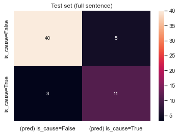

```python
import seaborn as sns
from sklearn.metrics import confusion_matrix


def evaluate_class(y, pred, class_name, title):
    print(f"accuracy: {accuracy_score(y, pred)}")

    conf_mat = confusion_matrix(y, pred)
    y_tick_labels = [f'{class_name}=False', f'{class_name}=True']
    x_tick_labels = ['(pred) ' + l for l in y_tick_labels]
    sns.set(rc={'figure.figsize':(7, 6)})
    sns.heatmap(conf_mat, xticklabels=x_tick_labels, yticklabels=y_tick_labels, annot=True, fmt='.3g').set(title=title)


evaluate_class(y_test[:, 0], pred_test[:, 0], 'is_cause', 'Test set (full sentence)')
```

```
accuracy: 0.8813559322033898
```

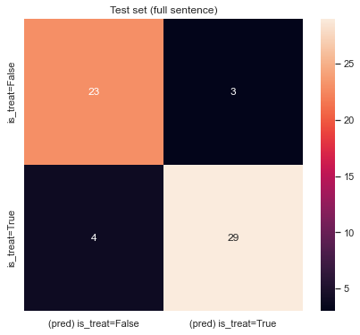

```python
evaluate_class(y_test[:, 1], pred_test[:, 1], 'is_treat', 'Test set (full sentence)')
```

```python
# Both predicted rightly
pd.set_option('display.max_colwidth', None)
pd.concat([pd.DataFrame(X_test.reset_index()), pd.DataFrame(y_test)], axis=1)[(pred_test == y_test).all(axis=1)].assign(
    pred_is_cause=pred_test[(pred_test == y_test).all(axis=1), 0],
    pred_is_treat=pred_test[(pred_test == y_test).all(axis=1), 1]
)
```

|  | index | prp_sent | 0 | 1 | pred_is_cause | pred_is_treat |
| --- | --- | --- | --- | --- | --- | --- |
| 0 | 507 | catechins, phytochemicals contained mainly in term1, exhibit antiviral activity against various acute term2 experimentally. | 0 | 1 | 0.0 | 1.0 |
| 1 | 563 | term1 products are believed to contain many bioactives that possess potential beneficial properties against term2. | 0 | 1 | 0.0 | 1.0 |
| 3 | 555 | in adult caucasian women, daily intake of 200-250 ml of term1 is associated with a reduction in term2 risk of 5 % or higher. | 0 | 1 | 0.0 | 1.0 |
| 4 | 90 | regular consumption of term1 (e.g., kimchi, kefir, etc.) may represent a potential avenue to counter the proinflammatory effects of term2. | 0 | 1 | 0.0 | 1.0 |
| 5 | 120 | extensive research over the last 10 years has indicated that nutraceuticals derived from such spices as turmeric, red pepper, black pepper, term1, clove, ginger, garlic, coriander, and cinnamon target… | 0 | 1 | 0.0 | 1.0 |
| 6 | 0 | interestingly, many indian tribes use term1 as a traditional medicine for the treatment of term2. | 0 | 1 | 0.0 | 1.0 |
| 7 | 172 | term1 is a driver of general and term2 in urban and rural areas. | 1 | 0 | 1.0 | 0.0 |
| 8 | 207 | proteins and peptides in term1 and bones are known for being rich in functional and nutritional ingredients for the improvement of term2. | 0 | 1 | 0.0 | 1.0 |
| 9 | 530 | our findings strongly suggest that some foods, especially term1, can act as a rich source of ãâãâãâãâ²-carbolines, which may possibly be associated with a reduced risk for serious term2, such a… | 0 | 1 | 0.0 | 1.0 |
| 11 | 434 | previously, we identified term1 as a natural compound possessing anti-term2 activity. | 0 | 1 | 0.0 | 1.0 |
| 12 | 314 | the association of term2, physical inactivity and term1 with elevated blood pressure (bp) is firmly established. | 0 | 0 | 0.0 | 0.0 |
| 13 | 88 | epicatechin (ec) and main colonic phenolic acids derived from flavonoid intake, such as 2,3-dihydroxybenzoic acid (dhba), 3,4-dihydroxyphenylacetic acid (dhpaa) and term1 (hppa), have been suggested t… | 0 | 1 | 0.0 | 1.0 |
| 15 | 491 | diallyl disulfide (dads), a component of term1 (allium sativum), has been known to exert potent chemopreventative activity against term2. | 0 | 1 | 0.0 | 1.0 |
| 17 | 124 | term1 has long been used in ancient china for the treatment of term2, asthma, and other lung diseases. | 0 | 1 | 0.0 | 1.0 |
| 18 | 346 | plant nutrients and plant-based diets could have beneficial effects in patients with term2: increased fibre intake shifts the gut microbiota towards reduced production of uraemic toxins; plant fats, p… | 0 | 1 | 0.0 | 1.0 |
| 21 | 477 | epidemiological studies have presented inconsistent evidence of the correlation between a term1-oriented dietary intake (fdi) and the risk of term2. | 0 | 0 | 0.0 | 0.0 |
| 22 | 189 | while it could be suggested that daily consumption of flavanols from cocoa or term1 would constitute a potential preventive tool useful for the nutritional management of term2, this recommendation sho… | 0 | 1 | 0.0 | 1.0 |
| 23 | 165 | exposure to term1 (cs) is associated with an increased risk of several term2 such as stroke, alzheimer's disease, and dementia. | 1 | 0 | 1.0 | 0.0 |
| 24 | 66 | regular intake of foods rich in saturated fats, such as term1 and certain dairy products, raises the risk of term2, especially in smokers. | 1 | 0 | 1.0 | 0.0 |
| 25 | 460 | occupational term2 to components of term1 is the main cause of rhinitis and asthma of workers in bakeries and similar activities. | 1 | 0 | 1.0 | 0.0 |
| 26 | 236 | term2 is a kind of occupational allergic rhinitis mainly caused by intranasal exposure to term1 and/or rye flour in bakery workers. | 1 | 0 | 1.0 | 0.0 |
| 27 | 480 | laboratory studies have provided evidence that allium vegetables and term1 might protect against term2 (crc), but epidemiologic studies have produced inconsistent findings. | 0 | 1 | 0.0 | 1.0 |
| 28 | 257 | term1 with vitamins and minerals has the potential to increase the nutrition in rice-consuming countries where term2 exist. | 0 | 1 | 0.0 | 1.0 |
| 29 | 13 | term1 is associated with various diseases including term2 and cancer. | 1 | 0 | 1.0 | 0.0 |
| 30 | 247 | term1, especially in liquid form, increases risk of term2, adiposity, and type 2 diabetes. | 1 | 0 | 1.0 | 0.0 |
| 31 | 438 | in subgroup analysis, term1 and yogurt consumptions were associated with decreased term2 risk (or = 0.87, 95% ci = 0.80-0.94 for term1 and or = 0. | 0 | 1 | 0.0 | 1.0 |
| 32 | 262 | high consumption of red meat, which is term2 to humans, and misuse or abuse of term1 drinking increase premature death and shortened life expectancy. | 0 | 0 | 0.0 | 0.0 |
| 33 | 92 | several studies have shown that a high consumption of vegetables and term1 is consistently associated with a low risk of oxidative stress-induced diseases, which includes some term2 such as amyotrophi… | 0 | 1 | 0.0 | 1.0 |
| 34 | 382 | staphylococcus aureus is the leading cause of clinical term2 and is associated with persistent subclinical infections in ewes, significantly compromising the quality and quantity of term1 productions. | 0 | 0 | 0.0 | 0.0 |
| 35 | 277 | the results reported in this study show the influence of gender, place of residence, smoking, consumption of term1, arthroscopy surgery, term2, and rheumatoid arthritis on the fe, ni, mo, and v concen… | 0 | 0 | 0.0 | 0.0 |
| 36 | 65 | use of term1 as food or food additives (such as spices) may prevent risk of term2, diabetes and cancer. | 0 | 1 | 0.0 | 1.0 |
| 37 | 414 | piscine orthoreovirus (prv-1) can cause term2 (hsmi) in term1 ( | 0 | 0 | 0.0 | 0.0 |
| 38 | 49 | term1 (l.), commonly called dandelion has been used for centuries as a natural medicine to treat term2 including some metabolic alterations associated with obesity. | 0 | 1 | 0.0 | 1.0 |
| 39 | 59 | epidemiological studies have compellingly documented the ability of the mediterranean diet rich in term1 to reduce the incidence of certain term2, and cardiovascular diseases, and slow the alzheimer's… | 0 | 1 | 0.0 | 1.0 |
| 41 | 283 | term1 is one of the major crops grown, processed and consumed by humankind and is associated with both intolerances (notably term2) and allergies. | 1 | 0 | 1.0 | 0.0 |
| 42 | 41 | for decades, occupational exposure to term1 has been linked to a range of term2, including occupational asthma, thought to result from exposure to fungi present in the flour. | 1 | 0 | 1.0 | 0.0 |
| 43 | 307 | in this context, term1 (evoo), the most representative component of this diet, seems to be relevant in lowering the incidence of cardiovascular events, including term2 and stroke. | 0 | 1 | 0.0 | 1.0 |
| 45 | 107 | the term1 aquaculture industry had remained relatively free of major term2 until the recent emergence of pilchard orthomyxovirus (pomv). | 0 | 0 | 0.0 | 0.0 |
| 47 | 242 | term1 are associated with a reduced reduction in the incidence of term2. | 0 | 1 | 0.0 | 1.0 |
| 50 | 305 | peanuts and nuts cause a great part of term2 in the united states; in spain and portugal are commonly due to fish, milk; in italy seafood and term1 in france. | 1 | 0 | 1.0 | 0.0 |
| 51 | 159 | consumption of term1 (olea europaea l.), including table term1 and oil, is associated with low incidence of term2-related diseases. | 0 | 1 | 0.0 | 1.0 |
| 52 | 132 | this review summarizes the mechanism and effects of dead sea salt, term1, commercial baby cleansers, oatmeal, rice, and natural oils as bathing additives for the treatment of term2. | 0 | 1 | 0.0 | 1.0 |
| 53 | 195 | jug r 1, the major allergen of term1, triggers severe term2 through epitopes. | 1 | 0 | 1.0 | 0.0 |
| 54 | 538 | term2 can be prevented by some simple and cost-effective steps such as smoking cessation, normalizing body weight, regular physical activity, and dietary changes, including decreasing saturated fats, … | 0 | 1 | 0.0 | 1.0 |
| 55 | 135 | recently, we demonstrated that term1 (wp) combined with low dietary fiber improved term2, a risk factor for cardiovascular disease in subjects with abdominal obesity. | 0 | 1 | 0.0 | 1.0 |
| 57 | 17 | further, waste products from tropical fruits including mangosteen rind, term1 pulp and spent term1 grounds provide further options to reduce term2. | 0 | 1 | 0.0 | 1.0 |
| 58 | 147 | the term1, one of the most popular natural materials, has been used to counter the effects of term2 in oriental medicine. | 0 | 1 | 0.0 | 1.0 |

```python
# At least one predicted wrongly
pd.concat([pd.DataFrame(X_test.reset_index()), pd.DataFrame(y_test)], axis=1)[~(pred_test == y_test).all(axis=1)].assign(
    pred_is_cause=pred_test[~(pred_test == y_test).all(axis=1), 0],
    pred_is_treat=pred_test[~(pred_test == y_test).all(axis=1), 1]
)
```

|  | index | prp_sent | 0 | 1 | pred_is_cause | pred_is_treat |
| --- | --- | --- | --- | --- | --- | --- |
| 2 | 23 | since term1 has been related to the development of chronic term2 prevalent in the western world, the use of sweeteners has gradually increased worldwide over the last few years. | 0 | 1 | 1.0 | 0.0 |
| 10 | 173 | portion sizes for term1 have been increasing dramatically in recent years alongside term2 rates, concurring with the phenomenon of the portion size effect (more is consumed when more is offered). | 1 | 0 | 0.0 | 0.0 |
| 14 | 47 | however, milk is a food of high nutritional value, and complete exclusion of term1 may favor the development of term2 such as osteopenia and osteoporosis. | 0 | 1 | 1.0 | 0.0 |
| 16 | 409 | in the last decade, several theories investigating the causes of term2 have been formulated and a condition or risk factor that can contribute is described by the gut-brain axis hypothesis: stress, te… | 1 | 0 | 0.0 | 0.0 |
| 19 | 187 | however, the validity of term1 as a treatment for term2 (ra), an autoimmune disorder, has not been confirmed yet. | 0 | 0 | 0.0 | 1.0 |
| 20 | 571 | however, there is also evidence of a detrimental effect of term1 on the risk of term2. | 0 | 1 | 1.0 | 0.0 |
| 40 | 179 | abundant studies have highlighted the protective effects of docosahexaenoic acid (dha), in the form of glycerolipids (glycerophosphatides and triglycerides) and dha-ethyl esters (dha-ee) in term2 (ad)… | 0 | 0 | 0.0 | 1.0 |
| 44 | 424 | we report a case of term2 to term1. | 0 | 0 | 1.0 | 0.0 |
| 46 | 535 | although a high intake of plant foods such as fruits, vegetables, whole grains, term1, and legumes has been recommended for term2 prevention, it has been unclear what is the optimal amount of intake o… | 0 | 1 | 0.0 | 0.0 |
| 48 | 543 | while term1 have been shown to exhibit serious side effects, and bioactive compounds from plant-based functional foods have been demonstrated to be active in the treatment of term2 with only minimal s… | 0 | 0 | 0.0 | 1.0 |
| 49 | 111 | term2 (brd) is a major cause of morbidity and mortality in term1 cattle. | 0 | 0 | 1.0 | 0.0 |
| 56 | 218 | term1 is a condition most commonly arising from the inadequate consumption of nutrients necessary to maintain physiological health and is associated with the development of term2, osteoporosis, and sa… | 1 | 0 | 0.0 | 0.0 |

```python
del model
del trainer
del train_dataset
del test_dataset
del val_dataset
```

### TorchLightning BERT CLS Classifier

```python
from pathlib import Path
import pandas as pd
import numpy as np
from transformers import AutoModel, AutoTokenizer
import evaluate
from datasets import Dataset
import torch
import torch.nn as nn
from sklearn.model_selection import train_test_split


torch.manual_seed(1)
np.random.seed(1)


tokenizer = AutoTokenizer.from_pretrained('emilyalsentzer/Bio_ClinicalBERT')
bert = AutoModel.from_pretrained('emilyalsentzer/Bio_ClinicalBERT')


X_train, X_test, y_train, y_test = train_test_split(sent_features.values, labels.values.astype('float'), test_size=0.1, shuffle=True, random_state=1)
X_train, X_val, y_train, y_val = train_test_split(X_train, y_train, test_size=0.1, shuffle=False)

X_train_tokens = tokenizer(list(X_train), truncation=True, padding=True)
X_val_tokens = tokenizer(list(X_val), truncation=True, padding=True)
X_test_tokens = tokenizer(list(X_test), truncation=True, padding=True)


class MedDataset(torch.utils.data.Dataset):
    def __init__(self, encodings, labels):
        self.encodings = encodings
        self.labels = labels

    def __getitem__(self, idx):
        X = [torch.tensor(val[idx]) for key, val in self.encodings.items()][0]
        y = torch.tensor(self.labels[idx])
        return X, y

    def __len__(self):
        return len(self.labels)


train_dataset = MedDataset(X_train_tokens, y_train)
val_dataset = MedDataset(X_val_tokens, y_val)
test_dataset = MedDataset(X_test_tokens, y_test)
```

[output not shown]

```python
from pathlib import Path

import torch
import torch.nn as nn
import torch.nn.functional as F
from torch.utils.data import Dataset
from torch.utils.data import DataLoader

from pytorch_lightning.core.lightning import LightningModule
from pytorch_lightning import Trainer
from pytorch_lightning.callbacks import ModelCheckpoint
from pytorch_lightning.callbacks.early_stopping import EarlyStopping
from pytorch_lightning.loggers import TensorBoardLogger


class TorchModel(LightningModule):
    def __init__(self, learning_rate=1e-05, weight_decay=1e-02) -> None:
        super().__init__()
        self.save_hyperparameters('learning_rate', 'weight_decay')
        self.bert = bert
        for param in self.bert.parameters():
            param.requires_grad = True
        self.classifier = nn.Linear(768, 2)

    def forward(self, x):
        x = self.bert(x)[0][:, 0, :]
        x = self.classifier(x)
        return x

    def _loss_fn(self, out, y):
        loss = nn.BCEWithLogitsLoss()(out, y)
        return loss

    def training_step(self, batch, batch_idx):
        x, y = batch
        out = self(x)
        loss = self._loss_fn(out, y)
        self.log('loss', loss, on_step=True, on_epoch=True, prog_bar=True, logger=True)
        return loss

    def validation_step(self, batch, batch_idx):
        x, y = batch
        out = self(x)
        loss = self._loss_fn(out, y)
        self.log('val_loss', loss, on_epoch=True, prog_bar=True, logger=True)

    def test_step(self, batch, batch_idx):
        x, y = batch
        out = self(x)
        loss = self._loss_fn(out, y)
        self.log('test_loss', loss, on_epoch=True, prog_bar=True, logger=True)

    def configure_optimizers(self):
        optim = torch.optim.AdamW(self.parameters(), lr=self.hparams.learning_rate, weight_decay=self.hparams.weight_decay)
        return optim


class TorchTrainer():
    def __init__(self, model, name, dirpath, dataloaders, max_epochs=30) -> None:
        self.model = model
        self.name = name
        self.dirpath = dirpath
        self.max_epochs = max_epochs
        self.dataloaders = dataloaders

    def run(self):
        logger = TensorBoardLogger(f'{self.dirpath}/tensorboard', name=self.name)
        callbacks = [
            ModelCheckpoint(dirpath=Path(self.dirpath, self.name), monitor='val_loss'),
            EarlyStopping(monitor='val_loss', patience=5, mode='min')]
        trainer = Trainer(logger=logger, callbacks=callbacks, max_epochs=self.max_epochs, gpus=1, num_sanity_val_steps=1)
        trainer.fit(self.model, self.dataloaders['train'], self.dataloaders['val'])
        trainer.test(self.model, self.dataloaders['test'])


train_dataloader = DataLoader(train_dataset, batch_size=32, num_workers=0, drop_last=False, pin_memory=True, shuffle=False)
val_dataloader = DataLoader(val_dataset, batch_size=64, num_workers=0, drop_last=False, pin_memory=True, shuffle=False)
test_dataloader = DataLoader(test_dataset, batch_size=64, num_workers=0, drop_last=False, pin_memory=True, shuffle=False)
dataloaders = {'train': train_dataloader, 'val': val_dataloader, 'test': test_dataloader}

model = TorchModel()
trainer = TorchTrainer(model, 'bert_cls', '../data/milestone3/bert_cls/', dataloaders, 50)
```

```python
trainer.run()
```

```
GPU available: True, used: True
TPU available: False, using: 0 TPU cores
IPU available: False, using: 0 IPUs
HPU available: False, using: 0 HPUs
LOCAL_RANK: 0 - CUDA_VISIBLE_DEVICES: [0]

  | Name       | Type      | Params
-----------------------------------------
0 | bert       | BertModel | 108 M
1 | classifier | Linear    | 1.5 K
-----------------------------------------
108 M     Trainable params
0         Non-trainable params
108 M     Total params
433.247   Total estimated model params size (MB)
```

```
Sanity Checking: 0it [00:00, ?it/s]
```

```
Training: 0it [00:00, ?it/s]
```

[output not shown]

[output not shown]

[output not shown]

[output not shown]

[output not shown]

[output not shown]

[output not shown]

[output not shown]

[output not shown]

[output not shown]

[output not shown]

[output not shown]

[output not shown]

[output not shown]

[output not shown]

[output not shown]

[output not shown]

[output not shown]

[output not shown]

[output not shown]

[output not shown]

[output not shown]

[output not shown]

[output not shown]

[output not shown]

[output not shown]

[output not shown]

```
LOCAL_RANK: 0 - CUDA_VISIBLE_DEVICES: [0]
```

```
Testing: 0it [00:00, ?it/s]
```

```
────────────────────────────────────────────────────────────────────────────────────────────────────────────────────────
       Test metric             DataLoader 0
────────────────────────────────────────────────────────────────────────────────────────────────────────────────────────
        test_loss           0.3478872321340871
────────────────────────────────────────────────────────────────────────────────────────────────────────────────────────
```